# MockComm_analysis

Lauren Bradford

01/04/2022

# Import and manage datasets

Imports rely on relative paths. Input files should be in same directory as Rmd file. Import data from Round 1-2 (both analysis rounds were run together)

```r
R12_table1 <- read.delim(here("R","Round1-2_results_table.txt"))

#Using tidyr to split fileID column
#FileID column has multiple pieces of information, split those into individual columns
R12_table1 <- separate(R12_table1, col=fileID, into=c("Comm", "Info"), sep="_kr2")

R12_table1 <- separate(R12_table1, col=Comm, into=c("Spike", "Rep"), sep="rep")

#Save a table with separate community column for doing positive library counts
R12_table2 <- R12_table1

#Need a column that combines Spike level, db, and confidence level
#Need for averaging replicates
R12_table1 <- unite(R12_table1, col="SpikeInfo", c('Spike', 'Info'), sep="_")
```

Import data from Round 3 (used only kr2bac database and confidence 0.25)

```r
R3_table1 <- read.delim(here("R","Round3_results_table.txt"))

#Split column with fileID to give useful columns (Spike in level, replicate, and confidence)
R3_table1 <- separate(R3_table1, col=fileID, into=c("Comm", "Conf"), sep="_kr2bac_")

R3_table1 <- separate(R3_table1, col=Comm, into=c("Spike", "Rep"), sep="rep")
```

Import data from Round 4 (same settings as round 3, 2 additional spikes: negative and 1000)

```r
R4_table1 <- read.delim(here("R","Round4_results_table.txt"))

#Split column with fileID to give useful columns (Spike in level, replicate, and confidence)
R4_table1 <- separate(R4_table1, col=fileID, into=c("Comm", "Conf"), sep="_kr2bac_")

R4_table1 <- separate(R4_table1, col=Comm, into=c("Spike", "Rep"), sep="rep")
```

Import data from Metaphlan4 analysis

```r
mp4 <- read.delim(here("R",'Mockcomm_metaphlan4.txt'))
```

Import data from CaecaSim

```r
CS_table1 <- read.delim(here("R","Caecasim_results_sorted.txt"))

CS_table1 <- separate(CS_table1, col=Library, into=c("Freq","Rep"), sep="rep")

CS_freqnum = c(4000000, 400000, 40000, 4000, 400, 40, 4, 0.4)
```

# Rounds 1-2 Analyses

### Average numerical data for replicates in Precision-Recall plots

```r
#Rearrange columns, I think?
R12_colnames <- colnames(R12_table1)
R12_colnames <- R12_colnames[-c(1,2,3,4,5)]

R12_avgs <- R12_table1 %>%
   group_by(SpikeInfo) %>%
   summarise_at(vars(all_of(R12_colnames)), mean)

R12_avgs <- separate(R12_avgs, col=SpikeInfo, into=c("Spike", "db", "conf"), sep="_")

head(R12_avgs)
```

```
## # A tibble: 6 × 17
##   Spike      db       conf  Senterica.reads.in.library S.ent.reads.correctly.I…¹
##   <chr>      <chr>    <chr>                      <dbl>                     <dbl>
## 1 salm100000 bac      c0                       100000                     98978.
## 2 salm100000 bac      c0.25                    100000                     93837
## 3 salm100000 bac      c0.5                     100000                     83117
## 4 salm100000 bac      c0.75                    100000                     58036.
## 5 salm100000 bac      c1                       100000                      9370.
## 6 salm100000 plrename c0                       100000.                    97763.
## # ℹ abbreviated name: ¹S.ent.reads.correctly.IDed
## # ℹ 12 more variables: S.ent.reads.assigned.higher <dbl>, Unclassified <dbl>,
## #   S.ent.reads.incorrectly.assigned <dbl>, Tot.reads.IDed.as.Salm <dbl>,
## #   False.positives <dbl>, Hits.to.SSRs <dbl>, S.ent.hits.to.SSRs <dbl>,
## #   SSRs.False.Pos <dbl>, Recall_Kr2 <dbl>, Recall_SSRs <dbl>,
## #   Precision.Kr2 <dbl>, Precision.SSRs <dbl>
```

### Make subsetted tables for each spike-in level

Used in PR plots

```r
salm100000_avgs <- subset(R12_avgs, Spike == "salm100000")
salm10000_avgs <- subset(R12_avgs, Spike == "salm10000")
salm100_avgs <- subset(R12_avgs, Spike == "salm100")
```

## Average + stddev of numerical data for replicates in bar plots

Step 1:

```r
#Make two dataframes, one for each of False positives by Kraken or FP by SSRcheck
#Only one dataframe needs to have the number of replicates (n=n())
#Otherwise the merge function gets annoyed by duplicate column
R12_avgs2 <- R12_table1 %>%
   group_by(SpikeInfo) %>%
   summarise(FalsePos_Kraken2=mean(False.positives), n=n(), sd_Kraken2=sd(False.positives))

R12_avgs3 <- R12_table1 %>%
   group_by(SpikeInfo) %>%
   summarise(FalsePos_SSRs=mean(SSRs.False.Pos), sd_SSRs=sd(SSRs.False.Pos))

#Merge the dataframes based on the Spikeinfo column
R12FP_avgs_stdevs <- merge(R12_avgs2, R12_avgs3, by="SpikeInfo")

#Delete the unnecessary intermediate dataframes
rm(R12_avgs2)
rm(R12_avgs3)
```

Step 2:

Melt those separate dataframes. Then merge together melted dfs. Then separate out the info columns

```r
#Separate out the means and the std devs into separate dfs.
#Melt those separate dataframes.
FP_means <- subset(R12FP_avgs_stdevs, select =c('SpikeInfo', 'FalsePos_Kraken2', 'FalsePos_SSRs'))

FP_means_melt =melt(FP_means, id.vars=c('SpikeInfo'))


FP_sds <- subset(R12FP_avgs_stdevs, select =c('SpikeInfo','sd_Kraken2', 'sd_SSRs'))
FP_sds_melt = melt(FP_sds, id.vars =c('SpikeInfo'))

#Rename the column, since FP_means also has different column named 'value'
FP_sds_melt <- rename(FP_sds_melt, sd=value)
#Remove all but the sd column, since SpikeInfo and variable are in other df that we will append to
FP_sds_melt <- within(FP_sds_melt, rm('SpikeInfo','variable'))

#Merge together directly
#Merging by SpikeID causes confusion because each ID exists twice
#Once for FP_Kraken2, once for FP_SSRs. This causes duplication and other problems
R12FP_melt <- cbind(FP_means_melt,FP_sds_melt)

#Split info column
R12FP_melt <- separate(R12FP_melt, col=SpikeInfo, into=c("Spike", "db", "conf"), sep="_")

#Remove c character from conf column
R12FP_melt$conf <- gsub("c","", as.character(R12FP_melt$conf))

#Remove separate tables now that they're merged
rm(FP_sds, FP_sds_melt)
rm(FP_means, FP_means_melt)
```

# Precision-recall plots

### Plotting averages for each spike-in level with just Kraken2

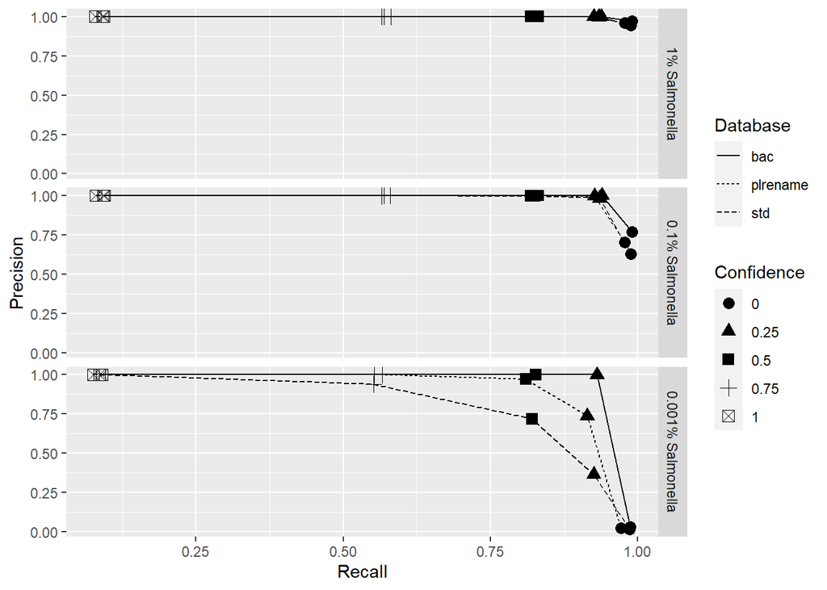

```r
libnames <- as_labeller(c(salm100000 = "1% Salmonella", salm10000 = "0.1% Salmonella", salm100 = "0.001% Salmonella"))

dbnames <- as_labeller(c(bac="kr2bac",plrename="kr2plrename",std="kr2std"))

#Remove c character from confidence column
R12_avgs$conf <- gsub("c","", as.character(R12_avgs$conf))

PRfig <- ggplot(R12_avgs, aes(x=Recall_Kr2, y=Precision.Kr2, label=conf)) +
  geom_point(size = 3, aes(shape=conf)) +
  geom_line(aes(linetype=db)) +
  facet_wrap(~fct_rev(Spike), ncol=1, strip.position = 'right', labeller = libnames) +
  xlab("Recall") +
  ylab("Precision") +
  labs(linetype = "Database", shape = "Confidence")
#fct_rev from forcats(tidyverse) reverses order of facets


PRfig
```

# Stacked bar plot of Salmonella assignments

```r
# Subset and melt the necessary data

salm100_bardata_melt = subset(salm100_avgs, select = c('Spike', 'db', 'conf','S.ent.reads.correctly.IDed','S.ent.reads.assigned.higher','Unclassified','S.ent.reads.incorrectly.assigned'))

#Rename columns
salm100_bardata_melt <- rename(salm100_bardata_melt, Salmonella=S.ent.reads.correctly.IDed,
                                HigherTaxa=S.ent.reads.assigned.higher,
                                Incorrect=S.ent.reads.incorrectly.assigned)

#Remove c character from conf column

salm100_bardata_melt$conf <- gsub("c","", as.character(salm100_bardata_melt$conf))

#Melt
salm100_bardata_melt <- melt(salm100_bardata_melt, id.vars=c('Spike', 'db', 'conf'))
```

Plot

```r
#Make stacked bar plot
barstack <- ggplot(salm100_bardata_melt, aes(x=value, y=conf, fill=variable)) +
  geom_bar(stat = "identity", position = position_stack(reverse = TRUE)) +
  facet_wrap(~db, ncol=1, strip.position = 'right') +
  xlab('Percent') +
  ylab('Confidence')
```

# Bar chart of false positives

Including std dev error bars

Reminder of dataframe structure. Value column = mean of 20 replicates sd = std dev of 20 replicates

```r
head(R12FP_melt)
```

```
##     Spike       db conf         variable  value       sd
## 1 salm100      bac    0 FalsePos_Kraken2 2972.2 38.47296
## 2 salm100      bac 0.25 FalsePos_Kraken2    0.0  0.00000
## 3 salm100      bac  0.5 FalsePos_Kraken2    0.0  0.00000
## 4 salm100      bac 0.75 FalsePos_Kraken2    0.0  0.00000
## 5 salm100      bac    1 FalsePos_Kraken2    0.0  0.00000
## 6 salm100 plrename    0 FalsePos_Kraken2 4140.2 37.16478
```

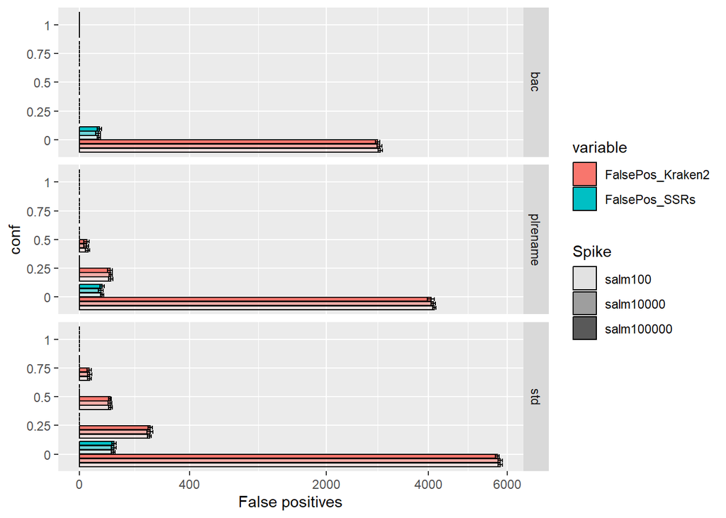

```r
barFP <- ggplot(data=R12FP_melt, aes(x=value, y = conf)) +
  geom_col(color = 'black', aes(fill = variable, alpha = Spike),
           #Colour by Kr2 vs. SSRcheck false positives,
           #Shade by spike-in level
           position = position_dodge2(width=2)) +
          #Dodge so it's not stacked, reverse order on y-axis
  scale_x_continuous(trans='sqrt',
                     breaks = c(0, 400, 2000, 4000, 6000)) +
  facet_wrap(~db, ncol=1, strip.position = 'right') +
  geom_errorbar(aes(xmin=value-sd, xmax=value+sd),
                position = position_dodge2(0.9)) +
  xlab('False positives')

barFP
```

```r
#Square root transformation on x-axis to better show small values
#Can't do log transformation because of many 0 values

#Don't use reverse = TRUE within position_dodge2, otherwise the bars will not line up with the error bars
```

Simplified bar plot for presentation: use only salm100 library.

```r
#Select only salm100 rows
R12FPsalm100_melt <- R12FP_melt[R12FP_melt$Spike == 'salm100',]

#Plot
barFP_salm100 <- ggplot(data=R12FPsalm100_melt, aes(x=value, y = conf)) +
  geom_col(aes(fill = variable),
           #Colour by Kr2 vs. SSRcheck false positives,
           position = position_dodge2(width=2)) +
          #Dodge so it's not stacked, reverse order on y-axis
  scale_x_continuous(trans='sqrt',
                     breaks = c(0, 400, 2000, 4000, 6000)) +
  facet_wrap(~db, ncol=1, strip.position = 'right', labeller = dbnames) +
  geom_errorbar(aes(xmin=value-sd, xmax=value+sd),
                position = position_dodge2(0.9)) +
  xlab('False positives') +
  ylab('Confidence') +
  theme(legend.position = 'bottom')
```

## Combined bar chart figures

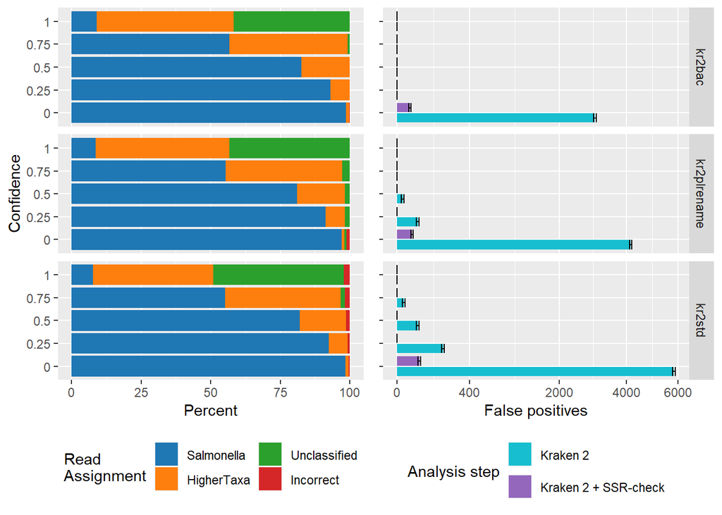

```r
Fig_bar <- ggarrange(barstack +
            theme(
              #Remove the facet label from left plot
              strip.text.y = element_blank(),
              legend.position = 'bottom') +
            #Change legend label and format
            labs(fill = 'Read\nAssignment') +
            guides(fill = guide_legend(nrow = 2)) +
            #Fun with colour palettes
  scale_fill_d3(),
          barFP_salm100 +
            theme(#Remove the y-axis label and numbers from right plot
              axis.text.y = element_blank(),
                  axis.title.y = element_blank(),
                  legend.position = 'bottom') +
            guides(fill = guide_legend(nrow = 2, byrow = TRUE))+
      #Re-name legend title and items
  scale_fill_manual(name="Analysis step",
                         breaks=c("FalsePos_Kraken2", "FalsePos_SSRs"),
                         labels=c("Kraken 2", "Kraken 2 + SSR-check"),
                      values=c("#17BECFFF","#9467BDFF")),
          ncol=2)
```

# Counts of positive libraries

```r
## Round1-2

#Subset the data to just spike-in level and number of confirmed hits
R12_subset = subset(R12_table2, Info == 'bac_c0.25')
R12_subset = subset(R12_subset, select = c('Spike','S.ent.hits.to.SSRs'))
#Remove characters so that the Spike column will be same in all analysis sets (R12, R3, metaphlan)
R12_subset$Spike <- gsub("salm","", as.character(R12_subset$Spike))

R12_kr2ssr_poslibcounts <- R12_subset %>%
  group_by(Spike) %>%
  summarize(Pipeline_positive_libraries = sum(S.ent.hits.to.SSRs > 0))

## Round 3
#Subset data and set Replicates as factor (required for heatmap)
r3_subset = subset(R3_table1, select = c('Spike','Rep','S.ent.hits.to.SSRs'))

#Remove characters so that the Spike column will be same in all analysis sets (R12, R3, metaphlan)
r3_subset$Spike <- gsub("salm","", as.character(r3_subset$Spike))

r3_poslibrarycounts <- r3_subset %>%
  group_by(Spike) %>%
  summarize(Pipeline_positive_libraries = sum(S.ent.hits.to.SSRs > 0))


## Round 4

r4_subset = subset(R4_table1, select = c('Spike','Rep','S.ent.hits.to.SSRs'))
r4_subset[,'Rep'] <- as.factor(r4_subset[,'Rep'])

#Remove characters so that the Spike column will be same in all analysis sets (R12, R3, metaphlan)
r4_subset$Spike <- gsub("salm","", as.character(r4_subset$Spike))

r4_poslibrarycounts <- r4_subset %>%
  group_by(Spike) %>%
  summarize(Pipeline_positive_libraries = sum(S.ent.hits.to.SSRs > 0))


## Metaphlan4

mp4_poslibrarycounts <- mp4 %>%
  group_by(Spike) %>%
  summarize(Metaphlan4_positive_libraries = sum(g__Salmonella > 0))


### Combine tables of positive libraries

#Combine kr2ssr Round1-2 (bac-c0.25 only) and Round3 and Round4 positive library counts
#Binding rows
pos1 <- rbind(r3_poslibrarycounts,R12_kr2ssr_poslibcounts,r4_poslibrarycounts)

#Add metaphlan4 column
pos2 <- merge(pos1,mp4_poslibrarycounts,by='Spike')

#Add replicates column (all spike levels had 20 reps)
pos2 <- pos2  %>%
  add_column(Replicates = 20)

#Re-order columns
pos_colorder <- c('Spike','Replicates','Pipeline_positive_libraries','Metaphlan4_positive_libraries')

pos2 <- pos2[, pos_colorder]

#Re-order rows
#Need to add 1000 and neg once I have all the data for those
xorder2 <- c('100000','10000','1000','100','50','10','5','neg')
pos_table <- pos2 %>%
  slice(match(xorder2, Spike))

#Give columns nice names for publishing
pos_table <- pos_table %>%
  rename('Salmonella reads in library' = 'Spike',
         'Positive libraries: Kraken2+SSRs' = 'Pipeline_positive_libraries',
         'Positive libraries: Metaphlan4' = 'Metaphlan4_positive_libraries')



#Clean up the many objects created
rm(pos1)
rm(pos2)
rm(R12_kr2ssr_poslibcounts)
rm(r3_poslibrarycounts)
rm(r4_poslibrarycounts)
rm(pos_colorder)
rm(xorder2)

#Display final table
pos_table
```

```
##   Salmonella reads in library Replicates Positive libraries: Kraken2+SSRs
## 1                      100000         20                               20
## 2                       10000         20                               20
## 3                        1000         20                               20
## 4                         100         20                               20
## 5                          50         20                               16
## 6                          10         20                               13
## 7                           5         20                               12
## 8                         neg         20                                0
##   Positive libraries: Metaphlan4
## 1                             20
## 2                             20
## 3                              4
## 4                              0
## 5                              0
## 6                              0
## 7                              0
## 8                              0
```

# CaecaSim analysis

```r
CS_markers <- subset(CS_table1, select = c('Freq', 'invA', 'stn'))

CS_markers_melt <- melt(CS_markers)
```

```r
CSmarkersplot <- ggplot(CS_markers_melt, aes(x = Freq, y = value)) +
  geom_point(aes(color = variable), position = position_jitter(width = 0.1, height = 0.1)) +
  scale_y_log10(labels = scales::label_log()) +
  scale_x_discrete(limits=rev,
                   labels = rev(CS_freqnum)) +
  xlab("Average Salmonella reads per library") +
  ylab('Marker gene hits') +
  labs(color = "Gene")  + scale_color_d3()


#Position=jitter is what's stopping points from lining up/all overlapping. Play with w and h.
```

```r
CSsalmplot <- ggplot(CS_table1, aes(x=Freq, y=Kr2_SSRconfirmed)) +
#  geom_boxplot() +
  geom_point(position = position_jitter(width = 0.1, height = 0.1)) +
  scale_y_log10(labels = scales::label_log(),
                breaks = c(1,10,100,1000,10000,100000,1000000)) +
  scale_x_discrete(limits=rev,
                   labels = rev(CS_freqnum)) +
  xlab("Average Salmonella reads in Library") +
  ylab('Salmonella read hits')

#Libraries have 40 million reads total
```

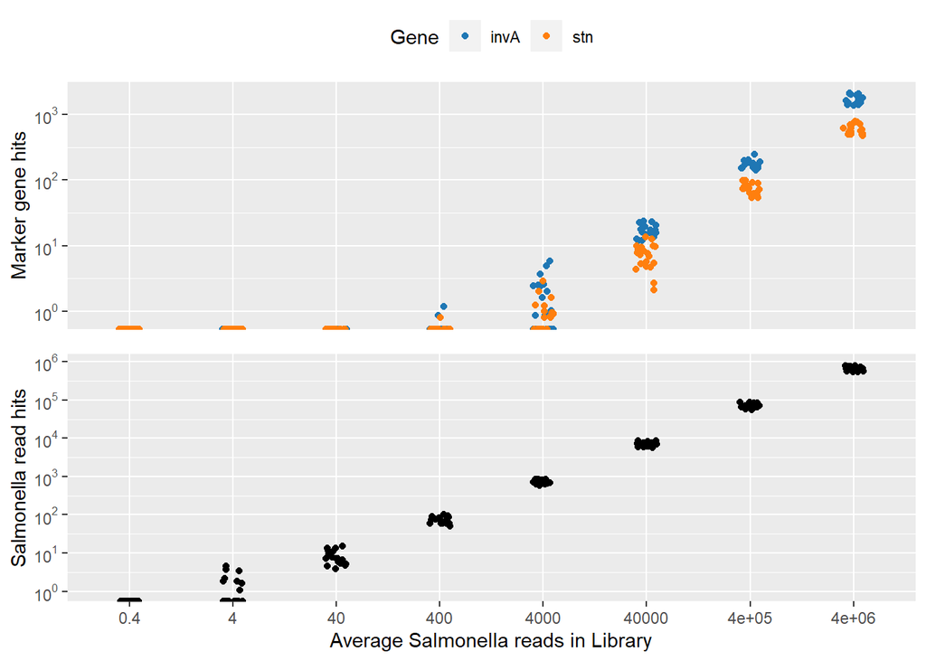

```r
Fig_detection <- ggarrange(CSmarkersplot +
  theme(axis.text.x=element_blank(),
        axis.ticks.x=element_blank(),
        axis.title.x = element_blank(),
        legend.position="top"),
          CSsalmplot,
          ncol=1)
```

Figure: Detection of Salmonella marker genes (top) or Salmonella-derived reads using the established workflow (bottom) in a chicken caecal microbiome background. Libraries contained 40 million reads.

Count detection in Caecaspike

```r
CS_markers$sumcol=rowSums(cbind(CS_markers$invA,CS_markers$stn),na.rm=TRUE)

CS_markers %>%
  group_by(Freq) %>%
  summarize(positive_libraries_markers = sum(sumcol > 0))
```

```
## # A tibble: 8 × 2
##   Freq  positive_libraries_markers
##   <chr>                      <int>
## 1 f1                            20
## 2 f2                            20
## 3 f3                            20
## 4 f4                            16
## 5 f5                             3
## 6 f6                             0
## 7 f7                             0
## 8 f8                             0
```

```r
CS_table1 %>%
  group_by(Freq) %>%
  summarize(positive_libraries_Kr2SSR = sum(Kr2_SSRconfirmed > 0))
```

```
## # A tibble: 8 × 2
##   Freq  positive_libraries_Kr2SSR
##   <chr>                     <int>
## 1 f1                           20
## 2 f2                           20
## 3 f3                           20
## 4 f4                           20
## 5 f5                           20
## 6 f6                           20
## 7 f7                            8
## 8 f8                            0
```

# Export figures

```r
ggsave("BarplotsComboFig.png", Fig_bar, path = here("R"), width = 17, height = 12, units = "cm")
```

```r
ggsave("caecasimFig.png", Fig_detection, path = here("R"), width = 16, height = 12, units = "cm")
```

```r
ggsave("PRfig.png", PRfig, path = here("R"), width = 18, height = 12, units = "cm")
```